# Military Organisation, Ranks, and Doctrine: A Structural Primer

Contents

Every army in history has had to solve the same problem: how do you direct thousands — or hundreds of thousands — of armed people, in the noise and chaos of a battlefield, so that their violence is applied to the right targets at the right time? The answer is hierarchy. Not bureaucratic habit, not tradition for its own sake, but a functional architecture that turns an undifferentiated crowd into an instrument capable of coordinated action.

This primer covers the organisational logic behind that architecture: ground-force echelons, ranks and appointments, the institutional role of non-commissioned officers, and the historical development of the modern system from the Napoleonic era onward. It also compares selected British, US, North Atlantic Treaty Organization (NATO), Chinese, and Russian arrangements where comparison exposes an important structural difference. It is not a field manual, an order of battle, a legal account of command authority, or a catalogue of every nation’s ranks and formations. Force tables, equipment, and active formations change; the contemporary examples are snapshots dated where that matters.

Unless a section explicitly says otherwise, the early hierarchy discussion uses a US Army/British Army ground-force reference model and NATO terminology. Its **Officer (OF)** and **Other Ranks (OR)** codes are a shared reference grid, not a claim that national titles or jobs are identical. A **non-commissioned officer (NCO)** is an enlisted leader who exercises authority within that system. A **Brigade Combat Team (BCT)** is a US Army combined-arms brigade, not a generic NATO formation. National-specific examples are labelled as such rather than presented as universal rules.

The focus is the industrial era — roughly the Napoleonic Wars to the present — because that is when modern military organisation solidified into its familiar shape. Pre-modern armies are touched on only to show what Napoleon’s innovations replaced. The assumed background is general technical and historical literacy; no military service, prior rank knowledge, or tactical training is required.

Verified against primary sources for sections 1–3 and 10; unverified claims are flagged inline.

# 1 The Logic of Military Hierarchy

The fundamental constraint on any organisation is the span of control: the number of subordinate units one commander can direct effectively. It is a design problem, not a universal headcount. US Army doctrine and historical practice often treat three to five subordinate manoeuvre units as a workable combat span, but the answer changes with mission, staff capacity, communications, readiness, terrain, and the need to coordinate supporting arms. A fire-team leader directs a few people directly; a well-staffed headquarters can coordinate far more subordinate organisations. The solution is nesting: teams form sections, sections form platoons, and so on, so that each commander has a manageable set of direct relationships. US Army [FM 6-0](https://home.army.mil/wood/application/files/8315/5751/8360/FM_6-0_I_Command_and_Staff_Organization_and_Operations.pdf) makes this dependence on task organisation explicit.

The often-invoked “rule of threes” is likewise a useful pattern rather than a law. Three subordinate manoeuvre elements can let a commander commit two and retain one as a reserve in some ground-combat problems. Other organisations use two, four, or more elements; support, fires, aviation, and logistics rarely fit the same neat pattern. These examples describe common arrangements, not a universal template; US Army doctrine treats span of control as a task-organisation consideration rather than a fixed numerical rule ([FM 3-94](https://rdl.train.army.mil/catalog-ws/view/100.ATSC/A4FC8E8D-7A8C-48F9-91FA-33A2490EACDA-1398867642924/fm3_94.pdf), paragraphs 2-69 onward).

Three terms recur throughout this primer and deserve careful definition.

**Echelon** means a level in the hierarchy — squad, platoon, company. All units at the same echelon share a position in the chain, regardless of their specific size or role.

**Formation** means an ad hoc grouping assembled for a specific mission, which may combine units from different echelons or arms. A task force is a formation; a battle group is a formation. Formations dissolve when the mission ends.

**Appointment** is the job someone is given; **rank** is the grade they hold permanently. A lieutenant colonel commands a battalion by appointment; if that appointment ends, they are still a lieutenant colonel. These can diverge significantly, especially in wartime when experience outpaces the promotion cycle. Understanding the distinction prevents confusion when, for example, a general officer is found commanding a force smaller than their rank would suggest.

# 2 The Building Blocks: From Fire Team to Battalion

The diagram shows a representative US/UK/NATO ground-force hierarchy; national structures and unit strengths vary.

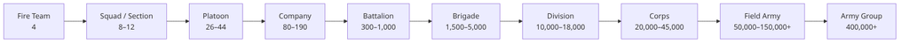

## 2.1 Fire Team and Squad

In the US Army infantry example, a **fire team** is a small tactical element, commonly organised around a single weapon system. Its traditional automatic weapon is the M249 light machine gun. The [M250 automatic rifle](https://cpeground.army.mil/Equipment/Equipment-Portfolio/PM-SL-Portfolio/M250-Automatic-Rifle/) is its planned replacement in the close-combat force and selected support units; the Army reported continued fielding in 2026 ([Army fielding update](https://cpeground.army.mil/News/Article-Display/Article/4445122/army-approves-xm8-carbine/)). A fire team commonly has a team leader and soldiers assigned roles such as automatic rifleman, grenadier, and rifleman. The team is small enough for direct leadership and personal example to matter more than elaborate command procedures.

In a common US Army infantry table, two fire teams and a squad leader form a **squad** of nine. Other armies use different strengths and internal arrangements. In the British Army the comparable infantry unit is a **section**, commonly led by a Corporal (NATO code OR-4); the US Army squad leader is commonly a Staff Sergeant (OR-6). These are national examples, not a cross-NATO rank rule. The squad or section is a basic manoeuvre element in infantry combat; it can fight independently for short periods but cannot sustain itself logistically.

## 2.2 Platoon

Three or four squads plus a small headquarters form a **platoon** of 26 to 44 soldiers. In the US Army a platoon is commanded by a Second Lieutenant (OF-1), the most junior officer grade, advised by a Sergeant First Class (OR-7) serving as Platoon Sergeant. In the British Army the Platoon Commander is a Lieutenant and the Platoon Sergeant a Sergeant; the platoon runs slightly smaller, typically 25 to 30. The Platoon Sergeant’s role is to run the platoon’s administration, logistics, and discipline so the officer can focus on tactics — a division of labour that repeats at every echelon of the hierarchy.

In the US and British infantry examples, the platoon is normally the lowest echelon led by a commissioned officer. Below it, day-to-day small-unit leadership normally falls to NCOs. Other services and national systems assign appointments differently.

## 2.3 Company

In the US Army the company commander is a Captain (OF-2), supported by a First Sergeant (OR-8), the senior NCO of the company and the commanding officer’s primary advisor on personnel and welfare. In the British Army the same appointment is held by a Major (OF-3). This is one of the most persistent sources of cross-national confusion: a British Captain (OF-2) shares the same code and title as a US Captain but is typically a company second-in-command or adjutant, not a company commander. A British Major (OF-3) and a US Captain (OF-2) do the same job at different NATO codes — functional counterparts despite a one-grade difference.

The company is the primary logistical unit in many armies: it holds organic transport, maintains supplies and ammunition, and cares for its own casualties before evacuation. Below company level, logistics is handled by the echelon above; the squad cannot feed and resupply itself independently.

## 2.4 Battalion

Three to five companies form a **battalion** of 300 to 1,000 soldiers, commanded by a Lieutenant Colonel (OF-4) and supported by a Command Sergeant Major (OR-9) or Regimental Sergeant Major. The battalion is the primary tactical unit in most Western armies: it is the smallest formation that combines all arms (infantry, organic mortars, reconnaissance elements, and often direct-fire anti-armour weapons) and has a headquarters capable of planning and coordinating multi-company operations over days. It has its own logistics train, medical section, and communications capacity.

In the US Army example, the Command Sergeant Major is the senior NCO in the formation and advises the commanding officer on matters touching soldiers’ welfare, discipline, and training; the British counterpart is the Regimental Sergeant Major. In these US and British models, battalion command is a commissioned-officer appointment. That is a feature of the reference systems, not a universal claim about every armed force.

The table summarises representative personnel ranges and command ranks for the US and British ground-force models.

| Echelon | Personnel | US Commander | NATO OF/OR | British Commander |
| --- | --- | --- | --- | --- |
| Fire Team | 4 | Sergeant (Corporal in practice) | OR-5 | Lance Corporal |
| Section / Squad | 8–12 | Staff Sergeant | OR-6 | Corporal |
| Platoon | 26–44 | Second Lieutenant | OF-1 | Lieutenant |
| Company / Squadron / Battery | 80–190 | Captain | OF-2 | Major (OF-3)† |
| Battalion | 300–1,000 | Lieutenant Colonel | OF-4 | Lieutenant Colonel |
| Brigade / BCT | 1,500–5,000 | Colonel | OF-5 | Brigadier (OF-6)† |
| Division | 10,000–18,000 | Major General | OF-7 | Major General |
| Corps | 20,000–45,000 | Lieutenant General | OF-8 | Lieutenant General |
| Field Army | 50,000–150,000+ | General (4-star) | OF-9 | General |
| Army Group | 400,000+ | General of the Army | OF-10 | Field Marshal |

† British functional counterparts differ by one grade: a British Major (OF-3) commands a company where a US Captain (OF-2) would; a British Brigadier (OF-6) commands a brigade where a US Colonel (OF-5) would.

# 3 The Brigade and Above: Operational Echelons

## 3.1 Brigade

In the US/UK/NATO reference model, three or more battalions, augmented with artillery, engineers, logistics, and reconnaissance, may form a **brigade** of roughly 1,500 to 5,000 soldiers. A manoeuvre brigade is often **combined arms** — meaning it brings together infantry, armour, fires, and support — but not every brigade is organised that way or can operate without augmentation. Below brigade level, battalions commonly depend on a higher formation for specialist capabilities and some sustainment.

The post-2003 US Army modular model created the **Brigade Combat Team (BCT)** as its primary combined-arms, close-combat formation. The familiar BCT types are the **Infantry Brigade Combat Team (IBCT)**, optimised for dismounted operations; the **Stryker Brigade Combat Team (SBCT)**, built around wheeled infantry carriers; and the **Armored Brigade Combat Team (ABCT)**, built around tanks and tracked mechanised infantry. This is a US Army model: exact BCT tables, equipment, and divisional assignments change with force design and mission. In the reference model, a BCT commander is a US Army Colonel (OF-5); British and many continental NATO brigades are commanded by a Brigadier or Brigadier General (OF-6).

## 3.2 Division

In the illustrative US Army model, two or more brigades plus aviation, artillery, engineers, and sustainment elements form a **division** of roughly 10,000 to 18,000 soldiers. The division commander is commonly a Major General (two stars, OF-7). A US Army division may contain several BCTs plus aviation, fires, and sustainment formations, but its exact mix is not a fixed international division standard.

The division is the lowest echelon that has its own organic aviation (attack helicopters, reconnaissance aircraft, and transport) and can therefore shape the battlefield beyond the range of its ground fires. It is also the primary echelon at which intelligence fusion occurs: the division has a dedicated intelligence staff capable of synthesising signals, imagery, and human intelligence rather than passing information up.

## 3.3 Corps

Two to five divisions, plus corps-level artillery, air defence, military intelligence, and logistics, form a **corps** of 20,000 to 45,000 soldiers, commanded by a Lieutenant General (three stars, OF-8). The corps is an operational rather than tactical echelon: it does not typically fight directly but coordinates the operations of its divisions across a theatre, synchronises joint fires (including close air support and naval gunfire), manages logistics across multiple lines of communication, and handles the interface with higher command and allied formations.

## 3.4 Field Army and Army Group

A **field army** of 50,000 to 150,000 or more soldiers groups two or more corps under a four-star General (OF-9). Above this, in large-scale coalition or theatre warfare, two or more field armies are grouped into an **army group**, historically commanded by a General of the Army or Field Marshal (OF-10, five-star) and numbering in the hundreds of thousands. The army group echelon was standard in both World Wars; today it is rarely activated in peacetime and would represent a wartime coalition command.

## 3.5 Task Forces and Ad Hoc Formations

Permanent formation tables are the peacetime baseline; war constantly demands improvisation. A **task force** is a temporary formation assembled from elements of different units and arms, designated by its mission or its commander’s name. In the Wehrmacht this was the **Kampfgruppe** — a battle group typically named for its commanding officer (Kampfgruppe Peiper, Kampfgruppe von Luck) and assembled from whatever infantry, armour, artillery, and engineers were available. The same principle appears in every modern army: because permanent formations cannot always be resized to fit the tactical problem, commanders assemble what they need from their available assets and give it a temporary designation.

# 4 Rank Systems: Officers, NCOs, and the Structure of Authority

## 4.1 The Three Categories

Military personnel divide into three categories with distinct bases of authority and distinct career paths.

**Enlisted soldiers** are the base of the pyramid. They enter with basic qualifications, receive trade training, and perform tactical duties under direction. Authority accrues through promotion, which reflects demonstrated competence and time served.

**Non-commissioned officers (NCOs)** are promoted enlisted personnel who have been appointed to leadership roles within the enlisted body. They do not hold a formal commission from the head of state; their authority derives from appointment by their chain of command and seniority within the system. The NCO corps is the institutional layer that translates officer orders into action, maintains day-to-day discipline and standards, trains junior soldiers, and advises officers who lack experience. The French call them *sous-officiers*; the Germans, *Unteroffiziere*. The NCO corps as a formally institutionalised layer of leadership — with its own career structure, training schools, and doctrinal role — is broadly a development of the 18th- and 19th-century European armies. Its quality is an important contributor to tactical effectiveness, especially where doctrine delegates initiative to small-unit leaders. Calling it the “single best predictor” would require comparative evidence this primer does not establish: officer leadership, training, cohesion, logistics, equipment, and the mission also affect performance.

**Commissioned officers** hold a formal appointment — historically a royal or presidential commission — and enter through an officer academy, university training corps, or officer candidate school, usually after tertiary education. They plan, command, and are legally accountable for their orders in ways that NCOs are not. The commission creates a formal distinction: officers exercise command authority; NCOs exercise supervisory authority delegated within that structure. In most armies the two career paths are nearly impermeable; an NCO who becomes an officer is the exception, not the rule, and the transition is treated as a significant institutional event.

## 4.2 Rank Versus Appointment

Rank is personal and permanent. Appointment is organisational and temporary. A Lieutenant Colonel is always a Lieutenant Colonel; whether they command a battalion, serve as a brigade chief of staff, or attend a staff college course is a matter of appointment. These can diverge considerably: in wartime, a colonel might be given a corps to command because no suitable general is available; a general might find themselves commanding a task force the size of a battalion. The rank describes the individual; the echelon describes the job.

## 4.3 NATO Standardisation: OF and OR Codes

NATO’s Standardization Agreement (STANAG) 2116 provides a common reference grid for ranks across member nations. Officers are coded OF-1 (most junior commissioned grade) through OF-10 (a wartime five-star grade, not in routine use); Other Ranks (OR) are coded OR-1 through OR-9. The indicators correspond to national ranks but do not make national titles or appointments identical ([NATO rank indicators](https://shape.nato.int/resources/site7234/General/BISCD040-002%20NATO%20NCO_JO%20Employment%20and%20Development%20Strat.pdf)). A British Captain (OF-2) and a US Captain (OF-2), for example, share a title and code, but their typical appointments differ. A British Major (OF-3) and a US Captain (OF-2) may both command companies despite holding different grades. The grid helps staff coordinate; it cannot erase national systems’ accumulated differences.

## 4.4 Comparative Rank Table

The table below maps NATO codes to national titles for three representative armies. Note that titles diverge considerably even when the structural role is identical.

| NATO Code | US Army | British Army | Bundeswehr |
| --- | --- | --- | --- |
| OR-1 | Private | Private (or Guardsman / Gunner / Sapper by arm) | Soldat |
| OR-2 | Private (PV2) | — | Gefreiter |
| OR-3 | Private First Class | Lance Corporal | Obergefreiter |
| OR-4 | Specialist / Corporal | Corporal | Stabsgefreiter |
| OR-5 | Sergeant | Sergeant | Unteroffizier |
| OR-6 | Staff Sergeant | Staff Sergeant / Colour Sergeant | Feldwebel |
| OR-7 | Sergeant First Class | — | Hauptfeldwebel |
| OR-8 | Master Sergeant / First Sergeant | Warrant Officer Class 2 | Stabsfeldwebel |
| OR-9 | Command Sergeant Major / Sergeant Major of the Army | Warrant Officer Class 1 | Oberstabsfeldwebel |
| OF-1 | Second Lieutenant / First Lieutenant | Second Lieutenant / Lieutenant | Leutnant / Oberleutnant |
| OF-2 | Captain | Captain | Hauptmann |
| OF-3 | Major | Major | Major |
| OF-4 | Lieutenant Colonel | Lieutenant Colonel | Oberstleutnant |
| OF-5 | Colonel | Colonel | Oberst |
| OF-6 | Brigadier General | Brigadier | Brigadegeneral |
| OF-7 | Major General | Major General | Generalmajor |
| OF-8 | Lieutenant General | Lieutenant General | Generalleutnant |
| OF-9 | General | General | General |
| OF-10 | General of the Army (dormant) | Field Marshal (effectively honorary) | — |

The British OR-8 and OR-9 slots are worth examining. British Warrant Officers Class 1 and 2 (WO1, WO2) occupy these codes, but they are not the same institution as US Army warrant officers. British WOs are senior NCO appointments — the Regimental Sergeant Major (RSM) is a WO1, the Company Sergeant Major (CSM) is a WO2 — and they are the apex of the NCO career path. They hold a warrant from the Defence Council rather than a commission, but they are not technical specialists; they are senior leaders.

## 4.5 Warrant Officers

The US Army’s warrant officer corps is a distinct structure, filling grades W-1 through W-5. Warrants are technical and tactical experts — helicopter pilots, intelligence analysts, special forces team leaders, cyber operators — who do not follow the standard commissioned officer career path. They have command authority within their speciality but typically do not command manoeuvre formations. A Chief Warrant Officer 5 (CW5) may have decades of mastery in a specific domain that no general officer would have; the warrant structure preserves that expertise outside the promotion-driven churn of the regular officer corps. Germany’s Bundeswehr has no equivalent category; those functions are distributed between NCOs and specialist officers.

## 4.6 Promotion and the Up-or-Out System

Promotion systems vary by service and period; the US Army’s promotion and continuation rules are statutory, not a single universal Western model. The [Defense Officer Personnel Management Act of 1980](https://uscode.house.gov/statutes/pl/96/513.pdf) established a statutory framework for officer personnel management, including promotion and separation provisions. The “up or out” approach aims to prevent stagnation in career grades; critics argue that it can also reward risk-averse career management. The latter is an institutional critique, not a measured effect established here.

## 4.7 Flag Officers and the Senior Grades

Officers above OF-5 (Colonel) enter the flag officer grades, named for the flag or pennant traditionally flown to mark a general’s or admiral’s headquarters.

**OF-6 (one star)**: Brigadier General in the US Army; Brigadier in the British Army. In the US Army, a one-star is a General officer. In the British Army, a Brigadier is explicitly *not* classified as a General officer by convention — a distinction that surprises most outsiders, since the French Général de brigade and German Brigadegeneral at the same NATO code are classified as general officers in their respective armies. The British Brigadier commands a brigade; the US Brigadier General typically serves as an assistant division commander or in a staff role rather than commanding a brigade.

**OF-7 (two stars)**: Major General; commands a division.

**OF-8 (three stars)**: Lieutenant General; commands a corps or serves as a theatre-level commander.

**OF-9 (four stars)**: General; commands a field army, a geographic combatant command, or serves as Chief of Staff of a service.

**OF-10 (five stars)**: General of the Army (US) or Field Marshal (UK and Commonwealth). The five-star grade was created in the United States in December 1944 primarily to address coalition protocol: as a four-star General, Eisenhower — the US Supreme Commander in Europe — was formally junior to the British Field Marshals (Montgomery and Alexander among them) serving under his command, an awkward inversion for a supreme commander. The new five-star grade of General of the Army restored parity, and for a supreme commander, seniority, over Allied five-star equivalents. The British Field Marshal grade predates the US General of the Army by centuries. Today, the grade is effectively dormant in both countries; the US has not promoted to five-star since Omar Bradley in 1950, and the British last held active Field Marshals in meaningful operational command during the Second World War. Modern field marshal appointments in the UK are essentially honorary dignities.

Napoleon’s Marshals of the Empire (*Maréchaux d’Empire*) deserve a note here. The rank of Maréchal was not a rank in the chain of command but a dignity — an appointment conferring enormous status and independent command authority. Napoleon created 26 of them between 1804 and 1815. They commanded corps and armies, but the dignity was personal to the individual, not tied to a specific echelon. A Maréchal commanding a corps and a Maréchal commanding three corps were both Maréchaux; the appointment described the person, not the job.

# 5 The British Regimental Tradition

The word “regiment” can confuse readers approaching British military organisation. In US Army and many other forces, a regiment can be a tactical formation of several battalions. In the British Army, an infantry regiment is primarily an administrative, cultural, and ceremonial body: a home for units and their identities, cap badges, and battle honours. Infantry battalions deploy as units; the regiment is not normally a field formation. The Ministry of Defence describes regiments and corps as administrative components made up of units ([2026 statistics](https://www.gov.uk/government/statistics/uk-armed-forces-equipment-and-formations-2026/uk-armed-forces-equipment-and-formations-2026)).

This distinction is the single most important thing to understand about the British system.

## 5.1 Origins and the Cardwell-Childers Reforms

The regimental system dates to the 17th century, when regiments were raised and owned by their colonels under royal commission. The colonel recruited, paid, clothed, and equipped the regiment from a royal allowance; the regiment bore his name. This system was chaotic and expensive, and it produced wide variation in quality and reliability. The first serious rationalisation came with the **Cardwell Reforms of 1872**, which divided Britain into approximately 66 regimental districts aligned with county boundaries. Each district had a depot and two battalions: one serving overseas (garrisoning the empire), one at home recruiting and training, feeding drafts to the overseas battalion. The **Childers Reforms of 1881** formalised this into the linked-battalion county regiment system, giving most regiments geographical names — the Durham Light Infantry, the Worcestershire Regiment, the Seaforth Highlanders — that connected them to a specific recruiting area and community.

This territorial anchoring served two purposes: a practical recruitment pipeline in a volunteer army, and a social bond between soldiers and their home communities that generated fierce regimental loyalty and fighting spirit. The system produced soldiers who identified primarily as members of the Gloucestershire Regiment or the Parachute Regiment rather than as generic members of the British Army.

## 5.2 The Cap Badge

The cap badge is the outward mark of regimental membership. Regimental identity and administrative organisation remain part of the British Army’s structure; current Ministry of Defence statistics describe regiments and corps as its largest permanent organisational components ([UK Armed Forces Equipment and Formations 2026](https://www.gov.uk/government/statistics/uk-armed-forces-equipment-and-formations-2026/uk-armed-forces-equipment-and-formations-2026)). Badges may incorporate county heraldry, a royal cypher, or a commemorative device, but the precise traditions differ by regiment.

## 5.3 Modern Amalgamations and Large Regiments

Post-war defence reductions forced successive rounds of amalgamation. Regiments that had maintained separate identities through two world wars were merged, producing hyphenated names that reflected often painful consolidations (the Duke of Edinburgh’s Royal Regiment, the Royal Anglian Regiment). The most recent wave under the Future Army Structure reorganisation created **large regiments**: multi-battalion administrative bodies that retain distinct battalion identities. The **Rifles** — the largest infantry regiment in the British Army — absorbed the Devon and Dorsets, the Light Infantry, the Royal Green Jackets, and the Royal Gloucestershire, Berkshire and Wiltshire Regiment. Soldiers serve in 1 Rifles, 4 Rifles, or 5 Rifles, but the cap badge and administrative home are The Rifles.

## 5.4 The Armoured Exception

In the Royal Armoured Corps, the regiment is the tactical unit, not a parent administrative body. An armoured regiment of roughly 550 soldiers and, depending on establishment, roughly 50 to 58 main battle tanks is the equivalent of an infantry battalion; it deploys and fights as a regiment, commanded by a Lieutenant Colonel. This reflects the different tactical geometry of armoured warfare, where a regiment-sized formation of tanks is the primary manoeuvre element, not a company-sized one.

## 5.5 Functional Corps

The British Army also uses “corps” in a functional rather than echelon sense. The Royal Artillery, Royal Engineers, Royal Corps of Signals, Royal Electrical and Mechanical Engineers (REME), and Adjutant General’s Corps are all “corps” — not tactical corps in the sense of two or three divisions, but institutional homes for soldiers in specialist trades. A gunner belongs to the Royal Artillery regardless of which battery or regiment they serve in. This use of “corps” to mean “branch of service” is distinct from the echelon corps (a formation of divisions) and has caused centuries of confusion when British officers speak to American counterparts.

# 6 The Napoleonic Inheritance: How Modern Structure Was Invented

## 6.1 The Pre-Napoleonic Army

Before the Revolutionary Wars, European armies had no permanent formation between the regiment and the army. Regiments were the highest persistent tactical and administrative units; everything above them — divisions, columns, wings — was assembled ad hoc for a specific campaign and dissolved when it ended. More important, regiments were strictly branch-specific: infantry regiments had no cavalry, cavalry regiments had no infantry, and artillery was collected in separate park commands. No formation below the army itself contained all three combat arms.

This imposed a decisive constraint on strategy. An army could not divide into independent formations because any detachment that separated from the main body was unbalanced: if it had only infantry, it could not screen, pursue, or reconnoitre; if it had only cavalry, it could not hold ground. The army moved as a single mass along a single route, limited in speed by the slowest element, in strategic reach by the need to stay together, and in deception by the impossibility of advancing on multiple axes simultaneously.

French theorists had identified this problem in the decades before the Revolution. Maurice de Saxe argued for permanent combined-arms formations in his 1757 *Mes Rêveries*. Marshal Broglie experimented with temporary divisions during the Seven Years’ War. The theorist Guibert, in his *Essai général de Tactique* (1772), advocated formations capable of operating independently. Jean de Bourcet theorised dispersed marching and rapid concentration. Napoleon read and re-read all of them. But the ideas were conceptual; no army had institutionalised them.

## 6.2 The Corps d’Armée

The diagram shows the corps as a permanent combined-arms formation, with divisions and specialist capabilities under one command.

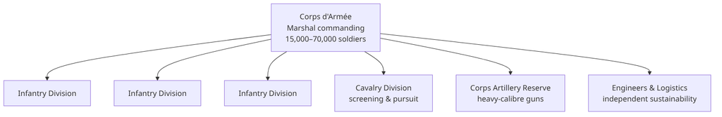

Napoleon trialled the corps system in 1800 in Moreau’s Army of the Rhine, then made it the permanent peacetime architecture of the whole French army during the camps of 1802–04, culminating in the Grande Armée organisation of 1804–05. The design solved the pre-Napoleonic problem directly. Each corps contained infantry divisions, a cavalry formation for screening and reconnaissance, a reserve of heavier artillery beyond what the divisions carried, engineer detachments, and a logistics train capable of sustaining the corps independently for days. Because any corps contained all three combat arms in organic assignment, it could engage and hold an enemy force while the rest of the army converged — which was, in essence, the operational method Napoleon used in every major campaign.

The practical working size of a corps was 20,000 to 30,000 soldiers, though Napoleon adjusted this widely by circumstance. Davout commanded 27,000 at Auerstedt in 1806 and drove an offensive victory against the Prussian main army of over 50,000 under the Duke of Brunswick — his III Corps attacked, routed a force twice its size, and broke the engagement before Napoleon’s own battle at Jena, twelve miles away, had concluded. The self-sufficiency of the corps meant that the Grande Armée could march on multiple axes, each corps a day’s march from the next — what Napoleon called the *bataillon carré* (square battalion), a loose formation of four corps arranged so that any two were within supporting distance of any threatened point. No army that marched as a single mass could match this for speed, strategic reach, or deception.

## 6.3 Spread and Legacy

The defeats of the War of the Fourth Coalition (1806–07) forced Prussia to adopt the corps system almost immediately. The reformers Scharnhorst and Gneisenau, working under the restrictions of the Treaty of Tilsit, restructured the Prussian army on Napoleonic lines; by 1813 the army that fought at Leipzig used permanent corps and divisions. Austria reformed after the catastrophic defeats of 1805 and 1809. Russia organised its forces into corps by the 1812 campaign. Even Britain, which never adopted the permanent peacetime corps, used Wellington’s divisions in the Peninsular War as the primary combined-arms manoeuvre element.

The structural legacy is direct and traceable. The modern US Army corps, commanded by a Lieutenant General and containing multiple divisions with organic artillery, engineers, and logistics, is the same functional architecture that Napoleon made permanent in 1804 and that Davout demonstrated at Auerstedt. Two centuries of incremental reform have changed the weapons, the vehicles, the communications, and the doctrine, but the basic answer to the span-of-control and combined-arms problems has not changed.

# 7 Twentieth-Century Adaptation: Three Organisational Revolutions

The Napoleonic inheritance — company to battalion to regiment to division to corps — survived into the 20th century largely intact. The industrial era introduced three innovations that modified but did not replace it.

## 7.1 Stormtroopers and Mission Command

The Western Front shattered the assumption that mass infantry assaults could break through fixed defences. Massed formations attacking across a broad front generated catastrophic losses for negligible gain; the problem was not courage but geometry. Machine guns, barbed wire, and pre-registered artillery fire turned any predictable, massed approach into a killing ground.

The German response was systematic and doctrinal. From 1915 onward, specialist assault units — *Stosstruppen* (stormtroopers) — developed new methods under officers like Captain Willy Ernst Rohr of Sturmbataillon Rohr. Rather than attacking in waves across the entire front, small groups of ten to twenty specialists — armed with grenades, pistols, light machine guns, flamethrowers, and light mortars — probed for weak points, bypassed strongpoints, and drove deep into the enemy rear, leaving isolated resistance for follow-on forces. The underlying principle was **infiltration**: find the gaps, exploit them fast, let momentum carry the attack forward before the defender can respond.

This required a fundamental change in how orders were given. Prescriptive orders — “advance at H-hour, cross the wire at this point, turn left at this landmark” — are useless to a small unit that has already bypassed the wire and is now 500 metres into the enemy position. Instead, orders stated the objective and allocated resources, then trusted subordinate leaders to find their own way. The Germans formalised this as *Auftragstaktik* — mission tactics — and it became the doctrine of the Reichswehr and then the Wehrmacht. A German junior officer or senior NCO was expected to act on initiative whenever the situation departed from the plan, without waiting for orders, so long as he kept the mission objective in mind. The contrast with the prescriptive, synchronised approach of most Allied armies in both world wars was stark, and it gave German formations at every echelon a speed of response that partially compensated for chronic material disadvantages.

## 7.2 The Panzer Division and Combined Arms at Scale

The second revolution was the **Panzer division**, which applied the combined-arms principle to mechanised warfare and proved, in the campaigns of 1939 and 1940, that speed and concentration could shatter armies before they could respond.

A fully equipped Panzer division contained a tank brigade of roughly 300 vehicles under the 1935 pattern (by 1940–41 divisions were restructured around a single tank regiment of under 200), two or more motorised infantry regiments, organic artillery capable of moving with the armour, anti-tank and anti-aircraft elements, an engineer battalion for obstacle breaching, a signals battalion, and a full logistics train. This was the first time all arms had been permanently integrated at division level and fully motorised — able to advance not at the pace of a walking infantryman (25 kilometres per day at best) but at the pace of wheeled and tracked vehicles (100 kilometres per day in good conditions). At Sedan in May 1940 Guderian’s XIX Corps covered 240 kilometres in four days, a strategic movement that the French had designed their entire defensive plan to make impossible.

Alongside the Panzer division, the Wehrmacht routinely employed the **Kampfgruppe** — an ad hoc battle group, usually named for its commander, assembled from whatever assets were available for a specific task. A Kampfgruppe might contain two tank companies, a motorised infantry battalion, a battery of self-propelled artillery, and a platoon of engineers: enough to be combined-arms capable without the full overhead of a division. The Kampfgruppe institutionalised tactical flexibility and allowed the Germans to concentrate force rapidly without waiting for formal orders restructuring the permanent chain of command.

## 7.3 Soviet Deep Battle

The third revolution was conceptual rather than purely technological. Soviet theorists in the late 1920s and 1930s — most notably Mikhail Tukhachevsky and Vladimir Triandafillov — developed the doctrine of **deep battle** (*glubokiy boy*): simultaneous attacks across the full depth of the enemy’s position, from front-line trenches to operational reserves to command nodes and supply lines, designed to paralyse the enemy’s ability to respond rather than simply pushing back his forward line.

Deep battle required a specific organisational answer: forces had to be echeloned so that a breakthrough echelon penetrated the forward defence, an exploitation echelon (typically mechanised or armoured) poured through the gap before the enemy could close it, and a reserve echelon exploited further to prevent consolidation. This was not the Napoleonic sequential battle — breakthrough, then pursuit — but a near-simultaneous attack on multiple echelons of depth. The doctrine was formalised in the Field Regulations of 1936 (PU-36), then suppressed when Tukhachevsky was executed in Stalin’s purge of the military in 1937, then rediscovered from necessity after the catastrophic losses of 1941.

Operation Bagration in June–August 1944 was the largest demonstration of deep battle at operational scale in military history. Four Soviet fronts (army groups) attacked Army Group Centre simultaneously on a 600-kilometre front. Mechanised and tank armies poured through the initial penetrations, encircling formations before they could withdraw, destroying Army Group Centre as a coherent force in six weeks. The Germans lost approximately 300,000 killed or captured; the Red Army advanced up to 600 kilometres. The operation was enabled by the Soviet organisational structure — multiple echelons of armoured and mechanised corps, managed through a front-level command that could coordinate operations across enormous distances — and by the Stavka (Soviet high command) reserve system that maintained fresh forces throughout.

The legacy of deep battle is direct in NATO doctrine. AirLand Battle, the US Army’s warfighting concept formalised in the 1982 and 1986 editions of FM 100-5, explicitly drew on Soviet deep battle theory to argue for simultaneous attacks against the enemy’s rear areas, disrupting reinforcement and supply before the ground battle was decided on the forward line. The modern concept of multi-domain operations descends from the same intellectual tradition.

# 8 Naval and Air Force Equivalents

## 8.1 The Navy: Rank Translation and Task Organisation

Naval rank titles are entirely different from army titles, though they occupy the same NATO pay grades. The most persistent source of confusion is the word “captain”: a naval Captain (O-6) is the equivalent of a Colonel, not an army Captain. Conversely, a naval Lieutenant (O-3) equals an army Captain. The table below shows the full officer equivalence.

| Pay Grade | US Navy | US Army Equivalent |
| --- | --- | --- |
| O-1 | Ensign | Second Lieutenant |
| O-2 | Lieutenant (Junior Grade) | First Lieutenant |
| O-3 | Lieutenant | Captain |
| O-4 | Lieutenant Commander | Major |
| O-5 | Commander | Lieutenant Colonel |
| O-6 | Captain | Colonel |
| O-7 | Rear Admiral (Lower Half) | Brigadier General |
| O-8 | Rear Admiral (Upper Half) | Major General |
| O-9 | Vice Admiral | Lieutenant General |
| O-10 | Admiral | General |
| O-11 | Fleet Admiral (dormant) | General of the Army |

Below the fleet level, naval formations are assembled by mission rather than permanent establishment, using **task organisation**. A fleet can generate **task forces** (TFs), commanded by a Commander, Task Force (CTF); task forces divide into **task groups** (TGs), commanded by a Commander, Task Group (CTG), and **task units** (TUs), commanded by a Commander, Task Unit (CTU). Designations such as Task Unit 62.5.3 express a hierarchical relationship to a numbered task force. The system lets a fleet re-designate forces, split task forces, and reassign ships as the mission changes ([U.S. Navy abbreviations](https://www.history.navy.mil/research/histories/ship-histories/abbreviations.html)).

The **Carrier Strike Group (CSG)** is a US Navy task-organised formation built around an aircraft carrier. Its accompanying ships and aircraft vary by mission and availability; a 2025 Navy deployment, for example, grouped a carrier, carrier air wing, destroyer squadron, and additional destroyers ([U.S. 2nd Fleet deployment announcement](https://www.navy.mil/DesktopModules/ArticleCS/Print.aspx?Article=4224355&ModuleId=3760&PortalId=1)). This is a combined-arms formation at sea, with air, surface, subsurface, and logistical capabilities. The composition is not a fixed table of organisation.

## 8.2 The Air Force: Squadron to Major Command

The US Air Force uses **flight**, **squadron**, **group**, **wing**, **numbered air force**, and **major command** as organisational levels. Their size, command grade, and precise relationships vary across mission types, so they do not map neatly onto ground-force echelons.

The Royal Air Force (RAF) uses distinctive rank terminology; the table gives approximate grade equivalents, not identical appointments:

| RAF Rank | Army Equivalent |
| --- | --- |
| Pilot Officer | Second Lieutenant |
| Flying Officer | Lieutenant |
| Flight Lieutenant | Captain |
| Squadron Leader | Major |
| Wing Commander | Lieutenant Colonel |
| Group Captain | Colonel |
| Air Commodore | Brigadier |
| Air Vice Marshal | Major General |
| Air Marshal | Lieutenant General |
| Air Chief Marshal | General |
| Marshal of the Royal Air Force | Field Marshal |

## 8.3 The “Squadron” Problem

The word “squadron” has different meanings across the armed forces. Naval squadrons group ships; air-force squadrons are flying units. In the British Army, an armoured or cavalry squadron is a company-level sub-unit; in the US Army, a cavalry squadron is a battalion-level formation whose company-equivalent sub-units are called troops. British Army organisation distinguishes infantry companies from armoured and cavalry squadrons, while US Army references describe cavalry squadrons at the battalion level ([UK unit terminology](https://assets.publishing.service.gov.uk/media/5a7901f640f0b676f4a7d22f/ea_need_for_militarytraining_august_2007.pdf); [US Army structure](https://www.army.mil/ranks/)). These labels are service- and nation-specific.

## 8.4 The Marine Air-Ground Task Force

The US Marine Corps answers the combined-arms question differently from the army. Rather than achieving combined arms at brigade or division level by attaching aviation from a separate air force command, the Marines organise into **Marine Air-Ground Task Forces (MAGTFs)**, which integrate ground combat, aviation, and logistics under a single command by design.

A MAGTF has a Ground Combat Element, an Aviation Combat Element, and a Logistics Combat Element. The smallest standard deployable MAGTF is the **Marine Expeditionary Unit (MEU)**; larger forms include the **Marine Expeditionary Brigade (MEB)** and **Marine Expeditionary Force (MEF)**. The MEU is normally embarked with an amphibious ready group, but personnel and aircraft composition vary by deployment. The Marine Corps overview illustrates a composite aviation element and its component detachments ([Amphibious Ready Group and MEU overview](https://www.marines.mil/portals/1/Amphibious%20Ready%20Group%20And%20Marine%20Expeditionary%20Unit%20Overview.pdf)).

The MAGTF model gives a combatant commander a self-contained expeditionary capability without the coordination overhead of synchronising army ground forces with an independent air force — at the cost of maintaining a dedicated aviation arm within the Marine Corps itself.

# 9 Beyond NATO: The Chinese PLA and Russian Armed Forces

The preceding sections have used Western armies as the reference frame. Two other forces deserve attention: the People’s Liberation Army (PLA), one of the world’s largest ground forces, and the Russian Armed Forces, whose campaign in Ukraine from 2022 has provided an unusually public window into the strengths and failures of a non-NATO structural model. The descriptions here reflect public sources checked on 12 October 2026; both forces continue to adapt in wartime and peacetime.

## 9.1 The People’s Liberation Army

The PLA’s continuing structural reorganisation began in 2015–2016. The reforms, formally announced in December 2015 and implemented through 2016, replaced the seven Military Region Commands then in existence with five Theatre Commands: Eastern (headquarters Nanjing, covering the Taiwan Strait and East China Sea), Southern (Guangzhou, South China Sea), Western (Chengdu, western borders with India and Central Asia), Northern (Shenyang, the Russian and Korean borders), and Central (Beijing, capital defence and strategic reserve). The reform separated force development — recruiting, training, equipping — from joint operational command. The services develop forces; the Theatre Commands direct joint operations in their assigned areas under the Central Military Commission (CMC). This broad division does not mean every strategic asset is delegated to a theatre commander.

The Chinese Ministry of National Defense’s [published structure](https://eng.mod.gov.cn/xb/News_213114/NewsRelease/16302071.html), checked on **12 October 2026**, distinguishes **four services** — Army, Navy, Air Force, and Rocket Force — from **four arms**: Aerospace Force, Cyberspace Force, Information Support Force, and Joint Logistic Support Force. Its 19 April 2024 announcement says all eight are under the Central Military Commission (CMC). This is the official organisational account, not an independent assessment of readiness or effectiveness.

This is a structural answer to the same joint operations problem NATO has wrestled with for decades. Theatre commanders have authority over all service components in their theatre, removing the inter-service coordination overhead that plagued earlier PLA operations. The reform explicitly studied the US combatant command structure, and the parallel is deliberate.

Public descriptions commonly identify the **Group Army** as a major PLA ground-force formation and combined-arms brigades as important subordinate formations. Exact subordinate structures are not fully transparent and change over time; the comparison with a Western corps is approximate, not a NATO equivalence.

The **Senior Colonel** (*dà xiào*) is a PLA grade between Colonel and Major General; it does not map directly onto a NATO officer grade. The grade was introduced in the 1955 rank system, removed when ranks were abolished in 1965, and restored in 1988. Current appointments vary, and claims about its typical assignment or proposed replacement require independent, dated sources; this primer does not treat them as established fact.

In December 2015 the PLA established the **Rocket Force**, replacing the Second Artillery Corps. It is one of the four services named in the Ministry’s 2024 structure announcement. Claims about its detailed operational responsibilities and the strategic rationale for its status go beyond that organisational source and should be treated as analysis rather than established fact.

## 9.2 The Russian Armed Forces: Reform, Reversal, and Ukraine

Post-Soviet Russia inherited the Soviet armed forces’ structure, culture, and equipment. The Soviet model was division-centric: a combined arms army controlled three or four divisions, each division with three regiments, each regiment with three battalions — a hierarchy designed for large-scale conventional war in Central Europe with manpower vast enough to absorb attrition.

Russia’s ground-force structure has changed repeatedly, and the war in Ukraine has accelerated reorganisation. A 2025 US Army analysis describes the Battalion Tactical Group as a semi-permanent task-organised reinforced battalion and documents substantial variation in how Russian formations were used ([How Russia Fights](https://api.army.mil/e2/c/downloads/2025/07/09/daa46f8a/no-25-1060-how-russia-fights-jul-25.pdf)). The exact 2026 district, army, division, and brigade structure remains uncertain in public sources; this primer does not present a fixed current order of battle.

The **Battalion Tactical Group (BTG)** was a Russian task-organised formation used before and during the 2022 invasion of Ukraine. Its size and composition were not fixed; estimates of headcount and dismounted infantry varied, so no single figure should be treated as a universal table. The US Army’s 2025 study describes BTGs as semi-permanent reinforced manoeuvre battalions and records variation in their organisation and employment. Limitations in sustainment, command, and infantry mass are analyses of performance, not properties shared identically by every BTG. Russian wartime structures continue to change, so claims about the BTG’s replacement should be dated and attributed rather than stated as a settled endpoint.

# 10 NATO Interoperability: Shared Standards and Persistent Friction

As checked on **12 October 2026**, NATO is a military alliance of [32 member countries](https://www.nato.int/en/what-we-do/introduction-to-nato), whose armed forces draw on different national traditions, equipment fleets, and doctrinal schools. Making them work together in a crisis requires a framework of shared standards, and NATO has built an extensive one. Its Standardization Agreements (STANAGs) cover matters from rank equivalence (STANAG 2116) to tactical symbology (Allied Procedural Publication 6 (APP-6), NATO joint military symbology), ammunition, fuel, radio procedures, and medical evacuation. The number and text of active standards change, so this is a description of the system rather than a current catalogue.

NATO’s **Enhanced Forward Presence (EFP)**, established in 2017 and reinforced after Russia’s full-scale invasion of Ukraine in 2022, provides a practical test case for interoperability. NATO’s [eastern-flank description](https://www.nato.int/en/what-we-do/deterrence-and-defence/strengthening-natos-eastern-flank), checked on **12 October 2026**, identifies **nine** multinational **Forward Land Forces (FLF)** battlegroups in Bulgaria, Estonia, Finland, Hungary, Latvia, Lithuania, Poland, Romania, and Slovakia. [FLF Finland began operations on 6 June 2026](https://www.nato.int/en/news-and-events/articles/news/2026/06/08/nato-enhances-security-in-the-arctic-and-high-north), with Sweden as framework nation. NATO says their size and composition vary, and that they can scale to brigade level where required. Contributors, readiness arrangements, and deployments can change.

The experience of EFP has clarified where standardisation genuinely works and where it has limits. Tactical symbology is broadly standardised and effective; staff officers from different nations can read each other’s maps. Fuel is partially standardised for NATO vehicles. But encrypted radio interoperability remains patchy; nations using national cryptographic systems cannot always communicate directly with allies without going through liaison elements. Command philosophy differs substantially: the US Army’s mission command doctrine, which devolves considerable authority to junior leaders to exercise initiative, sits uneasily alongside armies with more directive traditions in which detailed orders from above are the norm. And mixing units from different nations within a single company — as opposed to national companies within a multinational battalion — multiplies the coordination problem sharply enough that it is generally avoided below battalion level.

The FLF deployments provide forward defence and a base for reinforcement; their combat endurance depends on national contributions, brigade expansion, supporting forces, and sustainment. Article 5 concerns an armed attack on an Ally, not a minimum battlegroup size or an automatic military response. Each Ally takes the action it deems necessary under the [Treaty’s collective-defence provision](https://www.nato.int/en/what-we-do/introduction-to-nato/collective-defence-and-article-5). Integrating reinforcements, pre-positioned equipment, and existing forward forces under multinational command remains a central logistical and procedural challenge.

# 11 Further Reading

The literature on military organisation is extensive. The following works are starting points for each of the major themes in this primer.

**Military history and structure generally**: John Keegan, *The Face of Battle* (1976) — the canonical account of what battle actually looks like from the soldier’s perspective, with implications throughout for why organisation matters. Martin van Creveld, *Supplying War* (1977) — how logistics determines the organisational limits of military formations. Trevor Dupuy, *A Genius for War* (1977) — quantitative analysis of German military effectiveness, relevant to Auftragstaktik.

**The Napoleonic system**: David Chandler, *The Campaigns of Napoleon* (1966) — the standard reference for Napoleonic operational art, including the corps system in action. Rory Muir, *Tactics and the Experience of Battle in the Age of Napoleon* (1998) — how the structure translated into combat.

**20th-century organisation**: Robert Citino, *The German Way of War* (2005) — the doctrine of *Bewegungskrieg* (war of manoeuvre) and its organisational roots. Richard Overy, *Why the Allies Won* (1995) — the Soviet deep battle and industrial capacity case. Williamson Murray and Allan Millett (eds), *Military Innovation in the Interwar Period* (1996) — how the Panzer division and other innovations were developed between the wars.

**Organisation and modern US Army structure**: Department of the Army, *FM 6-0: Commander and Staff Organization and Operations* (2014), Appendix D — a useful starting point on span of control and task organisation. The US Army Center for Army Lessons Learned, *Multinational Interoperability Reference Guide* (2016), Appendix A — an accessible description of the familiar IBCT, SBCT, and ABCT model. *FM 3-0: Operations* (2022 edition) remains a core statement of US Army operational doctrine; force design and unit tables require a current source.

**Current NATO reference**: NATO, [Introduction to NATO](https://www.nato.int/en/what-we-do/introduction-to-nato) — membership; [Strengthening NATO’s eastern flank](https://www.nato.int/en/what-we-do/deterrence-and-defence/strengthening-natos-eastern-flank) — nine FLF battlegroups, including Finland. Checked 12 October 2026; these live institutional pages should be checked again before relying on force-structure details.

**PLA structure reference**: Chinese Ministry of National Defense, [PLA Embraces a New System of Services and Arms](https://eng.mod.gov.cn/xb/News_213114/NewsRelease/16302071.html), 19 April 2024 — four services and four arms; checked 12 October 2026. This is the official organisational account, not an independent assessment of operational effectiveness.

**Contemporary Russian formations**: US Army TRADOC, *How Russia Fights: A Compendium of Troika Observations on Russia’s Special Military Operation* (2025) — a dated military-analysis source on Russian task organisation and its wartime variation; it is an institutional assessment, not a complete order of battle.

**Ranks and the British system**: David Fraser, *And We Shall Shock Them: The British Army in the Second World War* (1983) — the regimental system under pressure. Allan Mallinson, *The Making of the British Army* (2009) — accessible historical survey from Marlborough to the present.